# R读入和处理SPSS、stata中文数据

liding@ruc.edu.cn

November 28, 2017

## 说在前面的话

R能够读入和处理SPSS和stata数据，但是R中因子型变量（factor变量，也就是分类变量）是数值变量和文本变量之外的一种单独的类型。而R会对不同的类型对象采取不同的处理方法，从而具有其他的优势，如回归模型因子变量自动作为虚拟变量纳入。

在SPSS和Stata数据中，实际上只存在两类变量，数值变量和文本变量，分类变量实际上只是带有标签的数值变量。你要他们相互加减乘除，机器也是可以做的，阻止如此做的只能是人。但是在R中，让两个分类变量相加，机器都不允许。

因此，为了发挥R的独特优势，我们读入stata和spss数据时，最好将spss和stata中带有标签的分类变量都转化为因子变量。但是SPSS和stata数据中不仅会给分类变量加标签，还会给数值变量加上用户缺失值标签。

那么如何处理这两类不同的标签呢？一种是不区分，统一读进来，将标签信息保存起来，读进来的数据作为一种特殊类型的变量。一种是读的时候就区分，全部取值都带来有标签的转变为因子，而标签不全的变量则保留标签信息但不转变为因子。

haven包和Daniel在haven基础上改进开发的sjmisc包采用的是前一种处理思路，读进来的变量都为labelled类型，变量标签和取值标签保存在变量的相关属性中。sjlabelled、sjPlot、sjstat等包可以调用,也可以通过设定好的函数依据标签转化为因子变量。

而foreign包和readstata13包采用的是第二种处理思路。在读入数据时可以通过一定的设定将带标签的分类变量转变为因子，而带用户缺失值标签的连续变量（标签不全的变量）仍然保持数值变量类型，但保留了取值标签信息，备查。

R还可以写出SPSS和Stata格式的数据。因此，当你只有某个较新版本的spss或者stata数据而手头的软件版本比较低时，除了让有新版本软件的朋友帮你另存为旧版本的数据或者使用statransfor之外，一种方法就是用开源的R读入新版本的数据，然后写出成为旧版本的数据，这里暂不讨论。

## 一、haven包读入SPSS、stata或SAS数据

Rstudio推荐使用haven包读入数据

```r
library(haven)
data1 <- read_sav("路径+文件名.sav")
data2 <- read_stata("路径+文件名.dta",encoding ="GB2312")
data3 <- read_sas("路径+文件名.sas7bdat")
```

haven包读人SPSS和Stata数据后，变量和取值标签变为变量的属性，变量默认为labelled类型。

Stata14之前的数据未存Encoding信息,需设定中文数据可能是GB2312编码。

SPSS数据和Stata14后版本支持unicode编码。haven可默认读入。

### 1.1 读Stata数据

当预览标签为乱码时，可尝试设定encoding=“GB2312”或者encoding=“gbk”。预览没有乱码时，意味着这数据encoding为默认的utf-8。

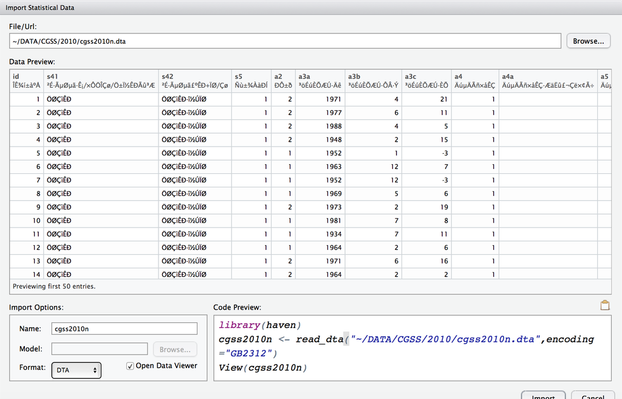

```r
library(haven)
cgss2003 <- read_dta("cgss2003.dta",encoding = "utf-8")
str(cgss2003$sitetype)
```

```
## Class 'labelled'  atomic [1:5894] 1 1 1 1 1 1 1 1 1 1 ...
##   ..- attr(*, "label")= chr "调查地类型"
##   ..- attr(*, "format.stata")= chr "%31.0g"
##   ..- attr(*, "labels")= Named num [1:7] -3 -2 -1 1 2 3 4
##   .. ..- attr(*, "names")= chr [1:7] "不适合" "无填答/不回答" "不知道/说不清" "直辖市/省会城市的市区" ...
```

```r
attr(cgss2003$sitetype,"label")
```

```
## [1] "调查地类型"
```

```r
attr(cgss2003$sitetype,"labels")
```

```
##                不适合         无填答/不回答         不知道/说不清
##                    -3                    -2                    -1
## 直辖市/省会城市的市区            地级市市区              县城城区
##                     1                     2                     3
##                  集镇
##                     4
```

### 1.2 读入SPSS数据

SPSS数据默认unicode编码,haven包的read_spss不能设定encoding信息。如果预览中spss数据标签等内容存在乱码，原数据的编码不一致，可以另存为低版本的spss统一编码形式然后haven读入或者使用后面的foreign包读入spss数据，它可以设定编码格式。

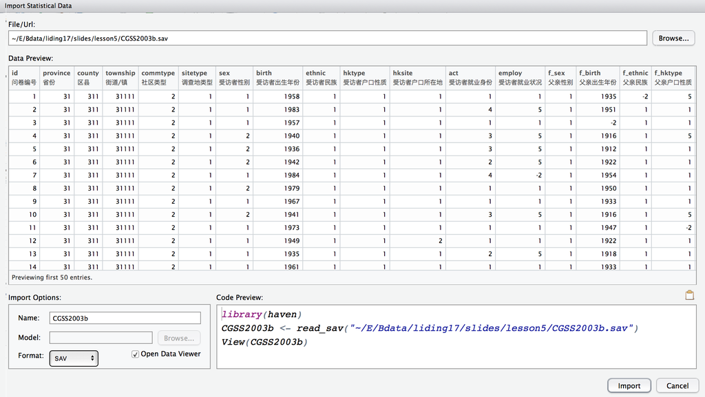

### 1.3 查看读入SPSS &Stata数据后的label信息

haven包默认导入spss和stata数据后,变量标签存在*变量*的的label属性当中,取值标签在labels属性当中。

```r
library(tidyverse)
library(haven)
cgss2003 <- read_sav("CGSS2003b.sav")  # spss7.0版数据
str(cgss2003$sitetype)
```

```
## Class 'labelled'  atomic [1:5894] 1 1 1 1 1 1 1 1 1 1 ...
##   ..- attr(*, "label")= chr "调查地类型"
##   ..- attr(*, "format.spss")= chr "F2.0"
##   ..- attr(*, "labels")= Named num [1:7] -3 -2 -1 1 2 3 4
##   .. ..- attr(*, "names")= chr [1:7] "不适合" "无填答/不回答" "不知道/说不清" "直辖市/省会城市的市区" ...
```

```r
attr(cgss2003$sitetype,"label")
```

```
## [1] "调查地类型"
```

```r
attr(cgss2003$sitetype,"labels")
```

```
##                不适合         无填答/不回答         不知道/说不清
##                    -3                    -2                    -1
## 直辖市/省会城市的市区            地级市市区              县城城区
##                     1                     2                     3
##                  集镇
##                     4
```

### 1.4 使用label信息

这些标签信息怎么使用呢？如果直接统计分析，输出中没有标签信息

```r
cgss2003 %>%  count(sitetype)
```

```
## # A tibble: 5 x 2
##    sitetype     n
##   <dbl+lbl> <int>
## 1        -2     1
## 2         1  2325
## 3         2  1527
## 4         3  1299
## 5         4   742
```

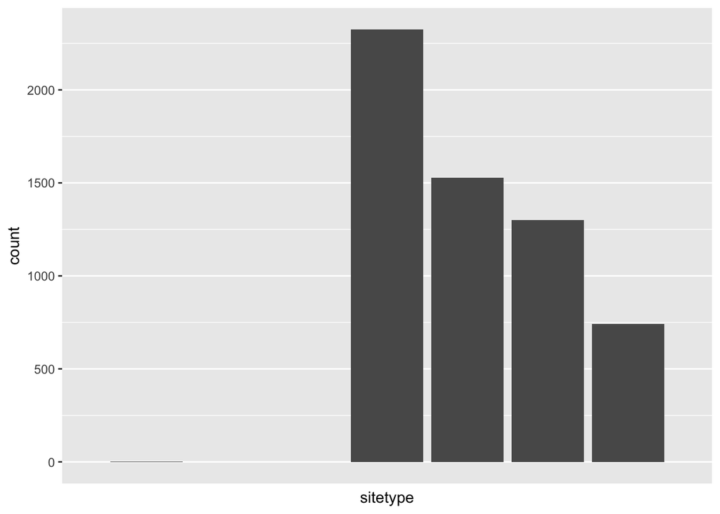

```r
ggplot(cgss2003, aes(x=sitetype)) +
  geom_bar() +
  scale_x_discrete(drop=TRUE)
```

### 1.5 使用label信息:使用sjPlot包分析

Daniel Lüdecke 专门研究了如何使用spss和stata数据导入附带的label信息，创建了一系列的包，并将之tidyverse化。

```r
#if(!require(sjmisc)) install.packages("sjmisc")
if(!require(sjPlot)) install.packages("sjPlot")
sjt.frq(cgss2003$sitetype)
```

调查地类型

| value | N | raw % | valid % | cumulative % |
| --- | --- | --- | --- | --- |
| 无填答/不回答 | 1 | 0.02 | 0.02 | 0.02 |
| 直辖市/省会城市的市区 | 2325 | 39.45 | 39.45 | 39.46 |
| 地级市市区 | 1527 | 25.91 | 25.91 | 65.37 |
| 县城城区 | 1299 | 22.04 | 22.04 | 87.41 |
| 集镇 | 742 | 12.59 | 12.59 | 100.00 |
| missings | 0 | 0.00 |  |  |
| total N=5894 · valid N=5894 · x̄=2.08 · σ=1.06 |  |  |  |  |

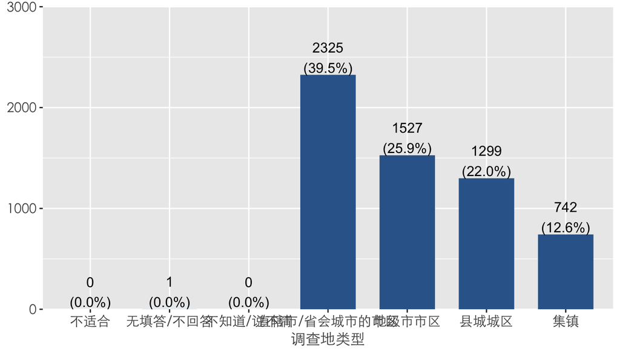

```r
sjp.setTheme(theme.font ='STXihei' ) # STHeiti也可
cgss2003  %>% select(sitetype) %>%  sjplot(fun="frq")
```

Daniel开发的 sjlabelled包中还有一些专门处理标签信息的函数，例如获得标签

```r
sjlabelled::get_labels(cgss2003$sitetype,include.values="n")

sjlabelled::set_labels(cgss2003$sitetype,
                       labels=c("不适合"="-3",
                                "无填答/不回答"="-2",
                                "不知道/说不清" = "-1",
                                "直辖市/省会城市的市区" = "1",
                                "地级市市区"  ="2",
                                "县城城区"="3" ,
                                "集镇" ="4" ))
```

mac中使用sjp中的作图函数绘制图形时，注意设定好字体，只有支持中文的字体才能在图形的标签元素（如标题）中呈现出来，如果是几何元素对应的标签，也需要设定，参见下面的解决方案。

[sjp更多介绍1](https://strengejacke.wordpress.com/2016/11/14/pipe-friendly-workflow-with-sjplot-sjmisc-and-sjstats-part-1-rstats-tidyverse/);

[sjp更多介绍2](https://strengejacke.wordpress.com/sjplot-r-package/);

[MAC电脑Rstudio作图中文乱码的解决方案](http://note.youdao.com/noteshare?id=9367dbf7c91458d07f54e256b6c2271d)

[可以用的中文字体名列表](http://www.cnblogs.com/code/articles/2381967.html)

### 1.6 使用label信息:将labelled分类变量转换为因子

使用haven包的as_factor()命令可以将labelled类型的变量变成因子，将变量的取值替换为标签本身。这是R数据处理分类变量的普遍方式。方式如下：

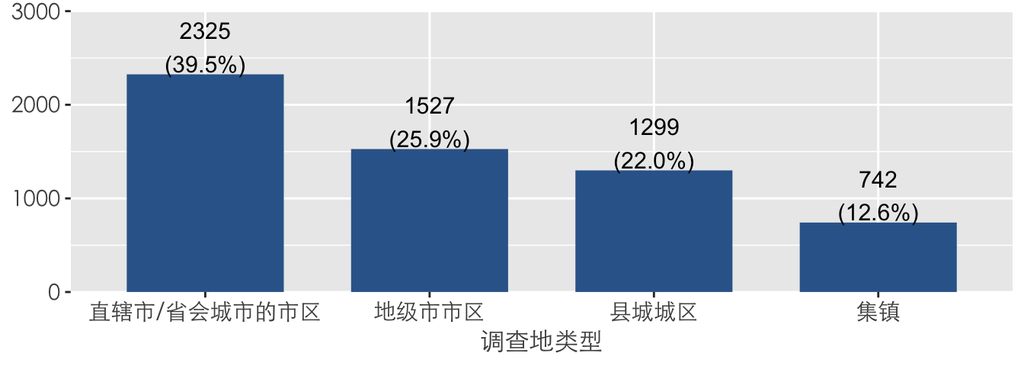

```r
cgss2003  %>%
  filter(sitetype>0) %>%
  select(sitetype) %>%
  haven::as_factor() %>%
  droplevels() %>%
  sjplot(fun="frq",axis.title="调查地类型")
```

### 1.7 使用label信息:将labelled分类变量转换为因子

SJ[(strange jack)](http://www.strengejacke.de/sjPlot/)的`sjmisc::to_label()`改进了haven包函数，不仅可以将所有labbled的列转为因子。还可以设定是否将用户定义的缺失值替换为NA(drop.na=TRUE)，删除未用到的取值标签(drop.levels=TRUE)。

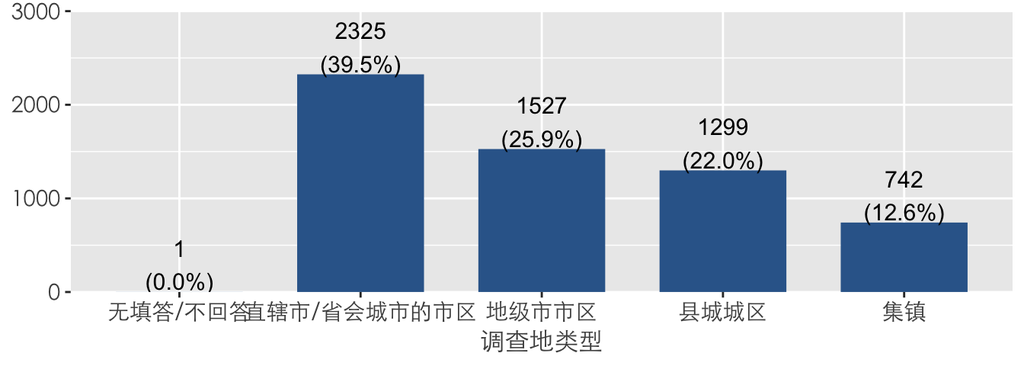

```r
cgss2003  %>%
  select(sitetype) %>%
  sjmisc::to_label(drop.levels=TRUE) %>%
  sjplot(fun="frq",axis.title="调查地类型")
```

### 1.8 删除连续变量中的用户缺失值标签

haven中的zap_labels可以删除标签，并将用户定义缺失值标签对应的取值替换为NA。但是很多数据集定义的用户缺失值只是加了标签并未明确设定。因此不好用。一种做法是在spss和stata中将这些特殊值如-1，-2，-3，9997，998 之类的明确定义为用户缺失值，然后再导入数据。

而sjlabelled包的zap_labels函数对haven包中的函数做了改进，可以将标签当做缺失值删除。当你处理的是连续变量时，少数几个用户缺失值标签通常是无用的，可以使用这一命令删除。

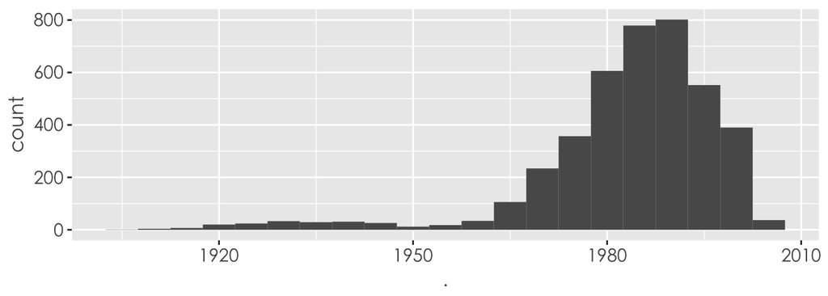

```r
cgss2003  %>%
  select(birth05) %>%
  sjlabelled::zap_labels() %>%
  qplot(binwidth=5)
```

Daniel开发的一系列包如sjlabelled、sjPlot、sjstat、sjmisc试图将SPSS和stata的数据存储和处理理念带回到R当中，并在数据分析是将标签自动加上。原来他可以同时使用haven包和foreign包读入数据，后来似乎靠向了haven包和tidyverse风格。如果你想保持stata和spss的数据结构概念，可以更多了解他开发的包。

https://github.com/strengejacke http://strengejacke.de/sjPlot/datainit/ https://cran.r-project.org/web/packages/sjmisc/index.html

### 1.9 Have包读入CGSS2003数据预处理的完整例子

```r
library(haven)
library(tidyverse)
# cgss2003 <- read_sav("CGSS2003b.sav")  # stata和spss都可以
cgss2003 <- read_stata("CGSS2003.dta")
#替换用户定义缺失值为系统缺失值
cgss2003[cgss2003==-1] <- NA;cgss2003[cgss2003==-2] <- NA;cgss2003[cgss2003==-3] <- NA
str(cgss2003$sitetype)
```

```
## Class 'labelled'  atomic [1:5894] 1 1 1 1 1 1 1 1 1 1 ...
##   ..- attr(*, "label")= chr "调查地类型"
##   ..- attr(*, "format.stata")= chr "%31.0g"
##   ..- attr(*, "labels")= Named num [1:7] -3 -2 -1 1 2 3 4
##   .. ..- attr(*, "names")= chr [1:7] "不适合" "无填答/不回答" "不知道/说不清" "直辖市/省会城市的市区" ...
```

```r
# 删除没有用到的取值标签
cgss2003 <- sjlabelled::drop_labels(cgss2003)

#将剩余取值标签的变量转为因子，无取值标签的变量仍然为labelled类型
str(cgss2003$sitetype)
```

```
## Class 'labelled'  atomic [1:5894] 1 1 1 1 1 1 1 1 1 1 ...
##   ..- attr(*, "label")= chr "调查地类型"
##   ..- attr(*, "format.stata")= chr "%31.0g"
##   ..- attr(*, "labels")= Named num [1:4] 1 2 3 4
##   .. ..- attr(*, "names")= chr [1:4] "直辖市/省会城市的市区" "地级市市区" "县城城区" "集镇"
```

```r
cgss2003 <- sjmisc::to_label(cgss2003) # as_label也可以用
# cgss2003 <- haven::as_factor(cgss2003)会将所有变量转成因子，不好
knitr::kable(as.data.frame(table(cgss2003$sitetype)))
```

| Var1 | Freq |
| --- | --- |
| 直辖市/省会城市的市区 | 2325 |
| 地级市市区 | 1527 |
| 县城城区 | 1299 |
| 集镇 | 742 |

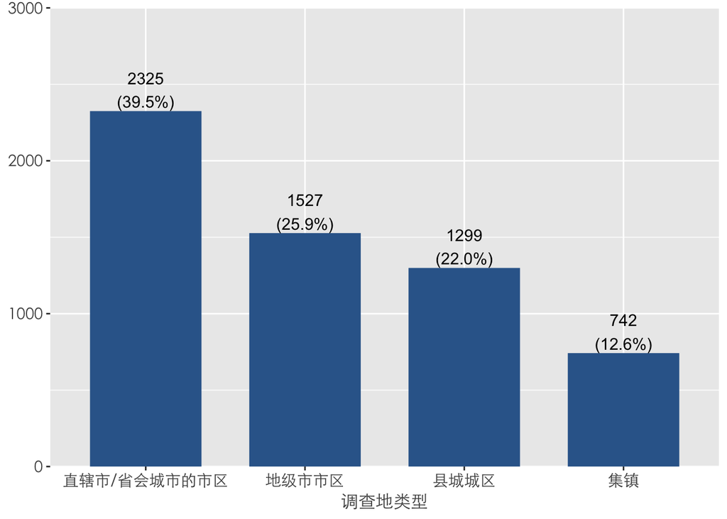

```r
#将剩余的labelled变量，都转化为普通数值变量
w <- which(sapply(cgss2003, class) == 'labelled')
cgss2003[w] <- lapply(cgss2003[w],
                      function(x) as.numeric(as.character(x))
                      )
sjPlot::sjp.setTheme(theme.font ='STXihei' )
cgss2003 %>%
  select(sitetype) %>% sjPlot::sjplot(fun="frq")
```

## 二、foreign包读入spss数据

除了haven包外，foreign包也是读入常见数据的较为成熟的包。它可以设定的参数更多。read.spss读入spss数据时，可设定reencode参数,对中文数据进行处理。

你可以设定是否读入标签信息、是否转变为数据框、设定因子变量多类数、删除因子标签中多于的空格、替换用户缺失值为NA、带有部分标签的变量如何处理等。

默认情况下是将所有带标签的变量转化为factor类型，如果有些取值没有label,会自动添加。

使用add.undeclared.levels=“no”,标签不全的变量不会转化为因子变量，但是会保留在变量的value.labels属性中。CGSS中那些定义了用户缺失值的连续变量最好采用这种方式读入，变成因子变量没有必要。

```r
cgss <- foreign::read.spss("CGSS2003.sav",reencode = "GB2312",to.data.frame=TRUE,add.undeclared.levels="no")
```

```
## re-encoding from GB2312
```

foreign包的`read.spss`导入的数据,变量标签存在于数据集的variable.labels属性当中。没有转变为因子变量的取值标签存在变量的value.labels属性中。

```r
attr(cgss, "variable.labels")[1:6]
```

```
##           id     province       county     township     commtype
##   "问卷编号"       "省份"       "区县"    "街道/镇"   "社区类型"
##     sitetype
## "调查地类型"
```

```r
attr(attr(cgss, "variable.labels")[1:6],"names")
```

```
## [1] "id"       "province" "county"   "township" "commtype" "sitetype"
```

```r
str(cgss$birth)
```

```
##  atomic [1:5894] 1958 1983 1957 1940 1936 ...
##  - attr(*, "value.labels")= Named chr [1:3] "-1" "-2" "-3"
##   ..- attr(*, "names")= chr [1:3] "不知道/说不清" "无填答/不回答" "不适合"
```

```r
attr(cgss$birth, "value.labels")
```

```
## 不知道/说不清 无填答/不回答        不适合
##          "-1"          "-2"          "-3"
```

```r
attr(attr(cgss$birth, "value.labels"),"names")
```

```
## [1] "不知道/说不清" "无填答/不回答" "不适合"
```

在R中我们可以批量删除某些用户定义的缺失值因子levels，以及连续变量中的用户缺失值。方法如下：

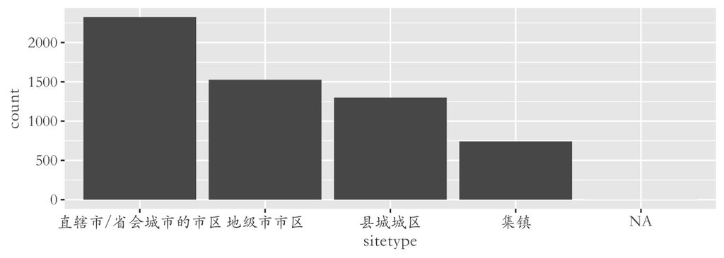

```r
cgss[cgss=="无填答/不回答"] <- NA
cgss[cgss=="不知道/说不清"] <- NA
cgss[cgss=="不适合"] <- NA
cgss[cgss=="不适用"] <- NA
cgss[cgss==-1] <- NA
cgss[cgss==-2] <- NA
cgss[cgss==-3] <- NA
cgss <- droplevels(cgss)
ggplot(data=cgss,aes(x=sitetype))+geom_bar() +theme(text=element_text(family="STKaiti"))
```

```r
#SimSun、SimHei 、STHeiti、 STXihei
```

## 三、readstata13包读入stata数据

foreign包的read.dta支持读入stata5-12的数据，可以设定的参数有限。现在已经过时了,可以使用readstata13包。它可以支持stata15及以前所有版本的stata数据文件，但如果是 Stata/MP 15创建的变量数超过 32,767的数据（119）可能存在问题，尚未测试。

readstata13 读入的标签信息在*数据集*的val.labels和label.table中。默认情况下convert.factors=TRUE，所有将带有标签的变量存为factor变量，标签不全的情况下会出现warning,且不会转为因子变量。convert.factors=FALSE设定会使得所有读入的变量都不转为因子变量，只保留标签信息。

cgss数据连续变量因为带有用户定义的缺失值标签，convert.factors=TRUE设定恰好合适，默认即可。这和foreign保持了一致。

```r
if(!require(readstata13)) install.packages("readstata13")
cgss <- read.dta13("cgss2003.dta",convert.factors=TRUE)
# 变量标签、变量取值标签
attr(cgss,"var.labels")[1:6]
```

```
## [1] "问卷编号"   "省份"       "区县"       "街道/镇"    "社区类型"
## [6] "调查地类型"
```

```r
attr(cgss,"val.labels")[1:6]
```

```
##         id   province       LABB       LABB   commtype   sitetype
##       "id" "province"     "LABB"     "LABB" "commtype" "sitetype"
```

```r
# 取值标签名
attr(attr(cgss,"val.labels")[1:6],"names")
```

```
## [1] "id"       "province" "LABB"     "LABB"     "commtype" "sitetype"
```

```r
# 取值标签表——有标签的才存在表中
attr(cgss,"label.table")[1:3]
```

```
## $strata
##        不适合 无填答/不回答 不知道/说不清          北京          天津
##            -3            -2            -1            11            12
##          上海  东部省会城市  中部省会城市  西部省会城市      东部区县
##            13            21            22            23            30
##      中部区县      西部区县
##            40            50
##
## $ordself
##           不适合    无填答/不回答    不知道/说不清 超过普通人的生活
##               -3               -2               -1                1
## 就是普通人的生活       不如普通人           说不清
##                2                3                4
##
## $ordclass
##                     不适合              无填答/不回答
##                         -3                         -2
##              不知道/说不清                 很受人尊敬
##                         -1                          1
##                 较受人尊敬             大家看得来就行
##                          2                          3
## 别人瞧得起、瞧不起都无所谓
##                          4
```

```r
attr(attr(cgss,"label.table")[1:3],"names")
```

```
## [1] "strata"   "ordself"  "ordclass"
```

```r
attr(cgss,"val.labels")["negotiat"]
```

```
##   negotiat
## "negotiat"
```

```r
attr(cgss,"label.table")$negotiat
```

```
##                 不适合          无填答/不回答          不知道/说不清
##                     -3                     -2                     -1
##     大力支持，积极参与     可以参与，但不出头 看看形势的发展再做决定
##                      1                      2                      3
##       无论如何也不参与                   其他
##                      4                      5
```

```r
table(cgss$negotiat)
```

```
##
##                 不适合          无填答/不回答          不知道/说不清
##                    104                     41                     96
##     大力支持，积极参与     可以参与，但不出头 看看形势的发展再做决定
##                   1807                   1445                   1120
##       无论如何也不参与                   其他
##                   1244                     37
```

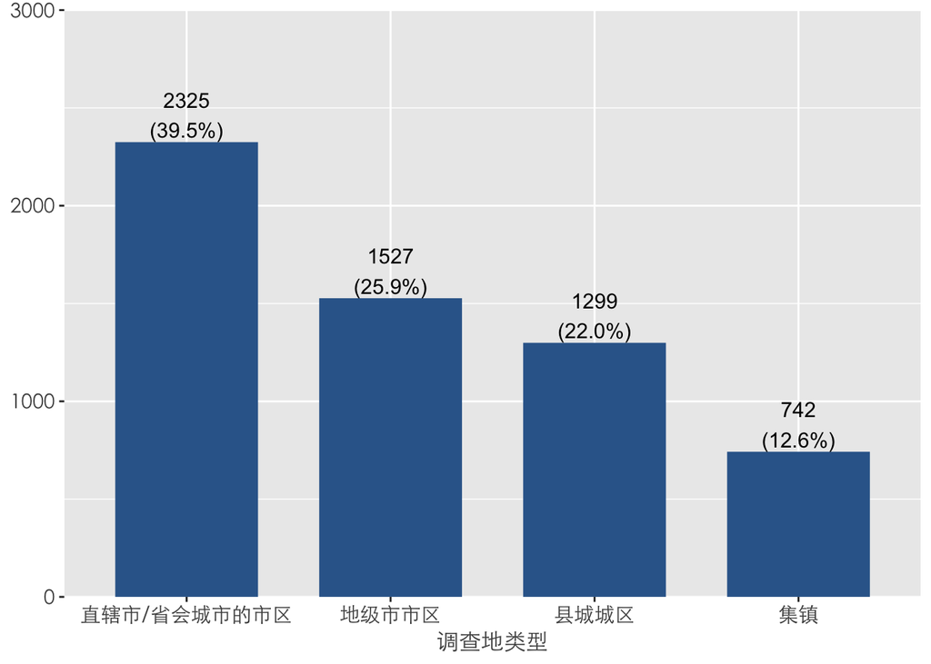

```r
cgss[cgss=="无填答/不回答"] <- NA
cgss[cgss=="不知道/说不清"] <- NA
cgss[cgss=="不适合"] <- NA
cgss[cgss=="不适用"] <- NA

cgss[cgss==-1] <- NA
cgss[cgss==-2] <- NA
cgss[cgss==-3] <- NA

cgss <- droplevels(cgss)

sjPlot::sjplot(cgss,sitetype,fun="frq",axis.title="调查地类型")
```

```r
sjPlot::sjt.frq(cgss$sitetype)
```

cgss$sitetype

| value | N | raw % | valid % | cumulative % |
| --- | --- | --- | --- | --- |
| 直辖市/省会城市的市区 | 2325 | 39.45 | 39.45 | 39.45 |
| 地级市市区 | 1527 | 25.91 | 25.91 | 65.37 |
| 县城城区 | 1299 | 22.04 | 22.04 | 87.41 |
| 集镇 | 742 | 12.59 | 12.59 | 100.00 |
| missings | 1 | 0.02 |  |  |
| total N=5894 · valid N=5893 · x̄=2.08 · σ=1.05 |  |  |  |  |

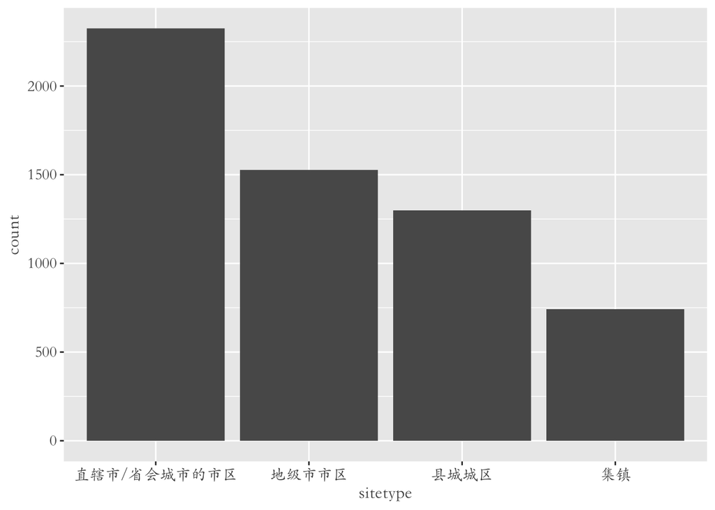

```r
ggplot(data=subset(cgss,!is.na(sitetype)))+
  geom_bar(aes(x=sitetype)) +
  theme(text=element_text(family="STKaiti"))
```

read.dta13的选项中，generate.factors=TRUE可以给标签不全的变量产生标签，这个不适用于CGSS数据，会将带有用户缺失值标签的连续变量变为因子变量。此外还可以设定将浮点数或双精度数加标签（这个也没有必要），或则选择一定的数据行。

通过encoding可以设定数据编码形式，stata14数据是utf-8编码，可以设定encoding = “NULL”停止转换。fromEncoding可以认为设定原数据编码样式。

## 四 针对中文数据的改进

陈华珊自定义的ezdf包针对中文做了一些改进，将变量标签存在了meta数据框中。它可分别设标签和文本变量的编码——有些情况下数据中的中文并不是采用相同的编码cgss2013的stata数据就是如此。这个包中还定义了简单的汇总函数，可将取值标签自动添加到汇总统计中。更多信息:https://github.com/huashan/ezdf/blob/master/Doc/Easy_Data.pdf

但这个包的系统性和更新频率不如strange jack。

```r
# 安装必要的包，运行一次即可
install.packages('data.table')
library(devtools)
options(download.file.method = "wininet")
install_git("https://github.com/huashan/ezdf")
install_github('huashan/pander')

# 加载包
library(ezdf)
dat <- readStata(file,varNameEncoding="GB2312",charEncoding="GBK")
```

更多R入门的内容请查看李丁的网站:http://www.istata.cn/?page_id=41